# Risk Factor Analysis

## Outcome Variable

**Outcome Variable:** whz

## Predictor Variables

**Intervention Variable:** exclfeed36

**Adjustment Set:**

- arm
- sex
- brthmon
- W_mage
- meducyrs
- feducyrs
- hhwealth_quart
- hfoodsec
- W_mhtcm
- W_mwtkg
- W_mbmi
- vagbrth
- W_gagebrth
- W_birthwt
- W_birthlen
- W_nrooms
- W_nchldlt5
- month
- W_parity
- impfloor
- impsan
- safeh20
- delta_W_mage
- delta_meducyrs
- delta_feducyrs
- delta_hhwealth_quart
- delta_hfoodsec
- delta_W_mhtcm
- delta_W_mwtkg
- delta_W_mbmi
- delta_vagbrth
- delta_W_gagebrth
- delta_W_birthwt
- delta_W_birthlen
- delta_W_nrooms
- delta_W_nchldlt5
- delta_month
- delta_W_parity
- delta_impfloor
- delta_impsan
- delta_safeh20

## Stratifying Variables

The analysis was stratified on these variable(s):

- agecat
- studyid
- country

## Data Summary

| agecat | studyid | country | exclfeed36 | n_cell | n | outcome_variable |
| --- | --- | --- | --- | --- | --- | --- |
| Birth | ki0047075b-MAL-ED | BANGLADESH | 1 | 31 | 208 | whz |
| Birth | ki0047075b-MAL-ED | BANGLADESH | 0 | 177 | 208 | whz |
| Birth | ki0047075b-MAL-ED | BRAZIL | 1 | 4 | 62 | whz |
| Birth | ki0047075b-MAL-ED | BRAZIL | 0 | 58 | 62 | whz |
| Birth | ki0047075b-MAL-ED | INDIA | 1 | 1 | 40 | whz |
| Birth | ki0047075b-MAL-ED | INDIA | 0 | 39 | 40 | whz |
| Birth | ki0047075b-MAL-ED | NEPAL | 1 | 0 | 25 | whz |
| Birth | ki0047075b-MAL-ED | NEPAL | 0 | 25 | 25 | whz |
| Birth | ki0047075b-MAL-ED | PERU | 1 | 5 | 218 | whz |
| Birth | ki0047075b-MAL-ED | PERU | 0 | 213 | 218 | whz |
| Birth | ki0047075b-MAL-ED | SOUTH AFRICA | 1 | 1 | 104 | whz |
| Birth | ki0047075b-MAL-ED | SOUTH AFRICA | 0 | 103 | 104 | whz |
| Birth | ki0047075b-MAL-ED | TANZANIA, UNITED REPUBLIC OF | 1 | 0 | 111 | whz |
| Birth | ki0047075b-MAL-ED | TANZANIA, UNITED REPUBLIC OF | 0 | 111 | 111 | whz |
| Birth | ki1000108-CMC-V-BCS-2002 | INDIA | 1 | 3 | 3 | whz |
| Birth | ki1000108-CMC-V-BCS-2002 | INDIA | 0 | 0 | 3 | whz |
| Birth | ki1000108-IRC | INDIA | 1 | 0 | 3 | whz |
| Birth | ki1000108-IRC | INDIA | 0 | 3 | 3 | whz |
| Birth | ki1000109-EE | PAKISTAN | 1 | 2 | 6 | whz |
| Birth | ki1000109-EE | PAKISTAN | 0 | 4 | 6 | whz |
| Birth | ki1017093b-PROVIDE | BANGLADESH | 1 | 115 | 483 | whz |
| Birth | ki1017093b-PROVIDE | BANGLADESH | 0 | 368 | 483 | whz |
| Birth | ki1101329-Keneba | GAMBIA | 1 | 343 | 1192 | whz |
| Birth | ki1101329-Keneba | GAMBIA | 0 | 849 | 1192 | whz |
| Birth | ki1113344-GMS-Nepal | NEPAL | 1 | 396 | 491 | whz |
| Birth | ki1113344-GMS-Nepal | NEPAL | 0 | 95 | 491 | whz |
| Birth | kiGH5241-JiVitA-3 | BANGLADESH | 1 | 6736 | 8619 | whz |
| Birth | kiGH5241-JiVitA-3 | BANGLADESH | 0 | 1883 | 8619 | whz |
| Birth | kiGH5241-JiVitA-4 | BANGLADESH | 1 | 1711 | 2128 | whz |
| Birth | kiGH5241-JiVitA-4 | BANGLADESH | 0 | 417 | 2128 | whz |

[output cut: 66 more lines]

The following strata were considered:

- agecat: 24 months, studyid: ki0047075b-MAL-ED, country: BANGLADESH
- agecat: 24 months, studyid: ki0047075b-MAL-ED, country: BRAZIL
- agecat: 24 months, studyid: ki0047075b-MAL-ED, country: INDIA
- agecat: 24 months, studyid: ki0047075b-MAL-ED, country: NEPAL
- agecat: 24 months, studyid: ki0047075b-MAL-ED, country: PERU
- agecat: 24 months, studyid: ki0047075b-MAL-ED, country: SOUTH AFRICA
- agecat: 24 months, studyid: ki0047075b-MAL-ED, country: TANZANIA, UNITED REPUBLIC OF
- agecat: 24 months, studyid: ki1000108-CMC-V-BCS-2002, country: INDIA
- agecat: 24 months, studyid: ki1000108-IRC, country: INDIA
- agecat: 24 months, studyid: ki1000109-EE, country: PAKISTAN
- agecat: 24 months, studyid: ki1017093b-PROVIDE, country: BANGLADESH
- agecat: 24 months, studyid: ki1101329-Keneba, country: GAMBIA
- agecat: 24 months, studyid: ki1113344-GMS-Nepal, country: NEPAL
- agecat: 24 months, studyid: ki1148112-LCNI-5, country: MALAWI
- agecat: 24 months, studyid: kiGH5241-JiVitA-3, country: BANGLADESH
- agecat: 24 months, studyid: kiGH5241-JiVitA-4, country: BANGLADESH
- agecat: 6 months, studyid: ki0047075b-MAL-ED, country: BANGLADESH
- agecat: 6 months, studyid: ki0047075b-MAL-ED, country: BRAZIL
- agecat: 6 months, studyid: ki0047075b-MAL-ED, country: INDIA
- agecat: 6 months, studyid: ki0047075b-MAL-ED, country: NEPAL
- agecat: 6 months, studyid: ki0047075b-MAL-ED, country: PERU
- agecat: 6 months, studyid: ki0047075b-MAL-ED, country: SOUTH AFRICA
- agecat: 6 months, studyid: ki0047075b-MAL-ED, country: TANZANIA, UNITED REPUBLIC OF
- agecat: 6 months, studyid: ki1000108-CMC-V-BCS-2002, country: INDIA
- agecat: 6 months, studyid: ki1000108-IRC, country: INDIA
- agecat: 6 months, studyid: ki1000109-EE, country: PAKISTAN
- agecat: 6 months, studyid: ki1000304b-SAS-FoodSuppl, country: INDIA
- agecat: 6 months, studyid: ki1017093b-PROVIDE, country: BANGLADESH
- agecat: 6 months, studyid: ki1101329-Keneba, country: GAMBIA
- agecat: 6 months, studyid: ki1113344-GMS-Nepal, country: NEPAL
- agecat: 6 months, studyid: ki1148112-LCNI-5, country: MALAWI
- agecat: 6 months, studyid: kiGH5241-JiVitA-3, country: BANGLADESH
- agecat: 6 months, studyid: kiGH5241-JiVitA-4, country: BANGLADESH
- agecat: Birth, studyid: ki0047075b-MAL-ED, country: BANGLADESH
- agecat: Birth, studyid: ki0047075b-MAL-ED, country: BRAZIL
- agecat: Birth, studyid: ki0047075b-MAL-ED, country: INDIA
- agecat: Birth, studyid: ki0047075b-MAL-ED, country: NEPAL
- agecat: Birth, studyid: ki0047075b-MAL-ED, country: PERU
- agecat: Birth, studyid: ki0047075b-MAL-ED, country: SOUTH AFRICA
- agecat: Birth, studyid: ki0047075b-MAL-ED, country: TANZANIA, UNITED REPUBLIC OF
- agecat: Birth, studyid: ki1000108-CMC-V-BCS-2002, country: INDIA
- agecat: Birth, studyid: ki1000108-IRC, country: INDIA
- agecat: Birth, studyid: ki1000109-EE, country: PAKISTAN
- agecat: Birth, studyid: ki1017093b-PROVIDE, country: BANGLADESH
- agecat: Birth, studyid: ki1101329-Keneba, country: GAMBIA
- agecat: Birth, studyid: ki1113344-GMS-Nepal, country: NEPAL
- agecat: Birth, studyid: kiGH5241-JiVitA-3, country: BANGLADESH
- agecat: Birth, studyid: kiGH5241-JiVitA-4, country: BANGLADESH

### Dropped Strata

Some strata were dropped due to rare outcomes:

- agecat: Birth, studyid: ki0047075b-MAL-ED, country: BRAZIL
- agecat: Birth, studyid: ki0047075b-MAL-ED, country: INDIA
- agecat: Birth, studyid: ki0047075b-MAL-ED, country: NEPAL
- agecat: Birth, studyid: ki0047075b-MAL-ED, country: SOUTH AFRICA
- agecat: Birth, studyid: ki0047075b-MAL-ED, country: TANZANIA, UNITED REPUBLIC OF
- agecat: Birth, studyid: ki1000108-CMC-V-BCS-2002, country: INDIA
- agecat: Birth, studyid: ki1000108-IRC, country: INDIA
- agecat: Birth, studyid: ki1000109-EE, country: PAKISTAN
- agecat: 6 months, studyid: ki0047075b-MAL-ED, country: NEPAL
- agecat: 6 months, studyid: ki0047075b-MAL-ED, country: SOUTH AFRICA
- agecat: 6 months, studyid: ki0047075b-MAL-ED, country: TANZANIA, UNITED REPUBLIC OF
- agecat: 6 months, studyid: ki1000108-CMC-V-BCS-2002, country: INDIA
- agecat: 6 months, studyid: ki1000108-IRC, country: INDIA
- agecat: 6 months, studyid: ki1000109-EE, country: PAKISTAN
- agecat: 6 months, studyid: ki1000304b-SAS-FoodSuppl, country: INDIA
- agecat: 24 months, studyid: ki0047075b-MAL-ED, country: NEPAL
- agecat: 24 months, studyid: ki0047075b-MAL-ED, country: PERU
- agecat: 24 months, studyid: ki0047075b-MAL-ED, country: SOUTH AFRICA
- agecat: 24 months, studyid: ki0047075b-MAL-ED, country: TANZANIA, UNITED REPUBLIC OF
- agecat: 24 months, studyid: ki1000108-CMC-V-BCS-2002, country: INDIA
- agecat: 24 months, studyid: ki1000108-IRC, country: INDIA
- agecat: 24 months, studyid: ki1000109-EE, country: PAKISTAN

## Methods Detail

We’re interested in the causal parameters $E[Y_a]$ for all values of $a \in \mathcal{A}$. These parameters represent the mean outcome if, possibly contrary to fact, we intervened to set all units to have $A=a$. Under the randomization and positivity assumptions, these are identified by the statistical parameters $\psi_a=E_W[E_{Y|A,W}(Y|A=a,W)]$. In addition, we’re interested in the mean of $Y$, $E[Y]$ under no intervention (the observed mean). We will estimate these parameters by using SuperLearner to fit the relevant likelihood factors – $E_{Y|A,W}(Y|A=a,W)$ and $p(A=a|W)$, and then updating our likelihood fit using a joint TMLE.

For unadjusted analyses ($W=\{\}$), initial likelihoods were estimated using Lrnr_glm to estimate the simple $E(Y|A)$ and Lrnr_mean to estimate $p(A)$. For adjusted analyses, a small library containing Lrnr_glmnet, Lrnr_xgboost, and Lrnr_mean was used.

Having estimated these parameters, we will then use the delta method to estimate relative risks and attributable risks relative to a prespecified baseline level of $A$.

# Results Detail

## Results Plots

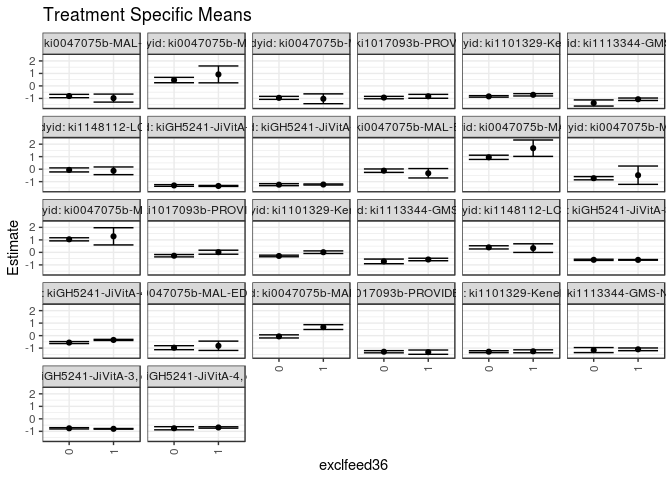

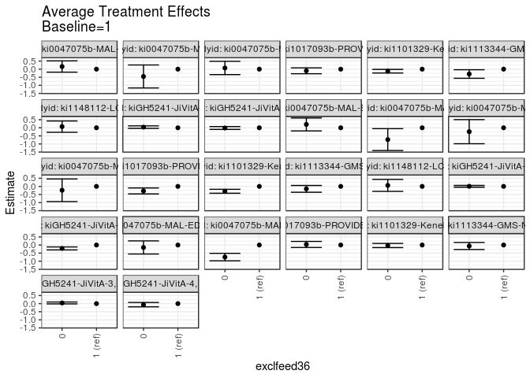

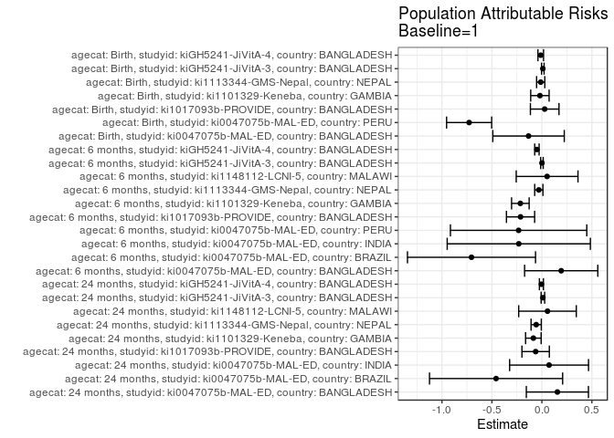

## Results Table

### Parameter: TSM

| agecat | studyid | country | intervention_level | baseline_level | estimate | ci_lower | ci_upper |
| --- | --- | --- | --- | --- | --- | --- | --- |
| Birth | ki0047075b-MAL-ED | BANGLADESH | 1 | NA | -0.8145323 | -1.1870106 | -0.4420541 |
| Birth | ki0047075b-MAL-ED | BANGLADESH | 0 | NA | -0.9664675 | -1.1259930 | -0.8069419 |
| Birth | ki0047075b-MAL-ED | PERU | 1 | NA | 0.6820000 | 0.4886003 | 0.8753997 |
| Birth | ki0047075b-MAL-ED | PERU | 0 | NA | -0.0629108 | -0.1888962 | 0.0630746 |
| Birth | ki1017093b-PROVIDE | BANGLADESH | 1 | NA | -1.3247021 | -1.4956014 | -1.1538028 |
| Birth | ki1017093b-PROVIDE | BANGLADESH | 0 | NA | -1.2896597 | -1.3780379 | -1.2012815 |
| Birth | ki1101329-Keneba | GAMBIA | 1 | NA | -1.2554784 | -1.3716900 | -1.1392668 |
| Birth | ki1101329-Keneba | GAMBIA | 0 | NA | -1.2867253 | -1.3643537 | -1.2090969 |
| Birth | ki1113344-GMS-Nepal | NEPAL | 1 | NA | -1.0966370 | -1.2047762 | -0.9884978 |
| Birth | ki1113344-GMS-Nepal | NEPAL | 0 | NA | -1.1575866 | -1.3584720 | -0.9567013 |
| Birth | kiGH5241-JiVitA-3 | BANGLADESH | 1 | NA | -0.7984834 | -0.8255537 | -0.7714131 |
| Birth | kiGH5241-JiVitA-3 | BANGLADESH | 0 | NA | -0.7567997 | -0.8090403 | -0.7045590 |
| Birth | kiGH5241-JiVitA-4 | BANGLADESH | 1 | NA | -0.6903298 | -0.7462428 | -0.6344167 |
| Birth | kiGH5241-JiVitA-4 | BANGLADESH | 0 | NA | -0.7540214 | -0.8803013 | -0.6277415 |
| 6 months | ki0047075b-MAL-ED | BANGLADESH | 1 | NA | -0.3285728 | -0.7045088 | 0.0473633 |
| 6 months | ki0047075b-MAL-ED | BANGLADESH | 0 | NA | -0.1223066 | -0.2595607 | 0.0149475 |
| 6 months | ki0047075b-MAL-ED | BRAZIL | 1 | NA | 1.6763283 | 1.0199506 | 2.3327060 |
| 6 months | ki0047075b-MAL-ED | BRAZIL | 0 | NA | 0.9470234 | 0.7775612 | 1.1164855 |
| 6 months | ki0047075b-MAL-ED | INDIA | 1 | NA | -0.4850000 | -1.2185777 | 0.2485777 |
| 6 months | ki0047075b-MAL-ED | INDIA | 0 | NA | -0.7254799 | -0.8547181 | -0.5962418 |
| 6 months | ki0047075b-MAL-ED | PERU | 1 | NA | 1.2841667 | 0.5956438 | 1.9726896 |
| 6 months | ki0047075b-MAL-ED | PERU | 0 | NA | 1.0459085 | 0.9221243 | 1.1696927 |
| 6 months | ki1017093b-PROVIDE | BANGLADESH | 1 | NA | 0.0145391 | -0.1452089 | 0.1742872 |
| 6 months | ki1017093b-PROVIDE | BANGLADESH | 0 | NA | -0.2666235 | -0.3619121 | -0.1713350 |
| 6 months | ki1101329-Keneba | GAMBIA | 1 | NA | 0.0144729 | -0.0909832 | 0.1199290 |
| 6 months | ki1101329-Keneba | GAMBIA | 0 | NA | -0.2870481 | -0.3505708 | -0.2235253 |
| 6 months | ki1113344-GMS-Nepal | NEPAL | 1 | NA | -0.5692323 | -0.6689743 | -0.4694904 |
| 6 months | ki1113344-GMS-Nepal | NEPAL | 0 | NA | -0.7223960 | -0.9091269 | -0.5356652 |
| 6 months | ki1148112-LCNI-5 | MALAWI | 1 | NA | 0.3404677 | -0.0051321 | 0.6860675 |
| 6 months | ki1148112-LCNI-5 | MALAWI | 0 | NA | 0.4017108 | 0.2745794 | 0.5288421 |
| 6 months | kiGH5241-JiVitA-3 | BANGLADESH | 1 | NA | -0.5999564 | -0.6291868 | -0.5707260 |
| 6 months | kiGH5241-JiVitA-3 | BANGLADESH | 0 | NA | -0.5954444 | -0.6442659 | -0.5466229 |
| 6 months | kiGH5241-JiVitA-4 | BANGLADESH | 1 | NA | -0.3460291 | -0.3920511 | -0.3000072 |
| 6 months | kiGH5241-JiVitA-4 | BANGLADESH | 0 | NA | -0.5574876 | -0.6380432 | -0.4769320 |
| 24 months | ki0047075b-MAL-ED | BANGLADESH | 1 | NA | -0.9742225 | -1.2935994 | -0.6548455 |
| 24 months | ki0047075b-MAL-ED | BANGLADESH | 0 | NA | -0.8104019 | -0.9433878 | -0.6774160 |
| 24 months | ki0047075b-MAL-ED | BRAZIL | 1 | NA | 0.9209801 | 0.2454887 | 1.5964715 |
| 24 months | ki0047075b-MAL-ED | BRAZIL | 0 | NA | 0.4693880 | 0.2552955 | 0.6834804 |
| 24 months | ki0047075b-MAL-ED | INDIA | 1 | NA | -1.0300000 | -1.4230980 | -0.6369020 |
| 24 months | ki0047075b-MAL-ED | INDIA | 0 | NA | -0.9551163 | -1.0754326 | -0.8348000 |
| 24 months | ki1017093b-PROVIDE | BANGLADESH | 1 | NA | -0.8319497 | -0.9890899 | -0.6748095 |
| 24 months | ki1017093b-PROVIDE | BANGLADESH | 0 | NA | -0.9329761 | -1.0283900 | -0.8375623 |
| 24 months | ki1101329-Keneba | GAMBIA | 1 | NA | -0.7120692 | -0.8056490 | -0.6184895 |
| 24 months | ki1101329-Keneba | GAMBIA | 0 | NA | -0.8383240 | -0.9007947 | -0.7758533 |
| 24 months | ki1113344-GMS-Nepal | NEPAL | 1 | NA | -1.0665483 | -1.1649913 | -0.9681052 |
| 24 months | ki1113344-GMS-Nepal | NEPAL | 0 | NA | -1.3669164 | -1.6128230 | -1.1210098 |
| 24 months | ki1148112-LCNI-5 | MALAWI | 1 | NA | -0.1331471 | -0.4419465 | 0.1756522 |
| 24 months | ki1148112-LCNI-5 | MALAWI | 0 | NA | -0.0607462 | -0.2232343 | 0.1017419 |
| 24 months | kiGH5241-JiVitA-3 | BANGLADESH | 1 | NA | -1.3452658 | -1.3839969 | -1.3065348 |
| 24 months | kiGH5241-JiVitA-3 | BANGLADESH | 0 | NA | -1.3043875 | -1.3708154 | -1.2379596 |
| 24 months | kiGH5241-JiVitA-4 | BANGLADESH | 1 | NA | -1.2294888 | -1.2712762 | -1.1877014 |
| 24 months | kiGH5241-JiVitA-4 | BANGLADESH | 0 | NA | -1.2423813 | -1.3224945 | -1.1622682 |

### Parameter: E(Y)

| agecat | studyid | country | intervention_level | baseline_level | estimate | ci_lower | ci_upper |
| --- | --- | --- | --- | --- | --- | --- | --- |
| Birth | ki0047075b-MAL-ED | BANGLADESH | NA | NA | -0.9480769 | -1.0934921 | -0.8026617 |
| Birth | ki0047075b-MAL-ED | PERU | NA | NA | -0.0458257 | -0.1696487 | 0.0779973 |
| Birth | ki1017093b-PROVIDE | BANGLADESH | NA | NA | -1.2966874 | -1.3774293 | -1.2159454 |
| Birth | ki1101329-Keneba | GAMBIA | NA | NA | -1.2752643 | -1.3442810 | -1.2062476 |
| Birth | ki1113344-GMS-Nepal | NEPAL | NA | NA | -1.1085743 | -1.2077878 | -1.0093609 |
| Birth | kiGH5241-JiVitA-3 | BANGLADESH | NA | NA | -0.7892308 | -0.8133344 | -0.7651272 |
| Birth | kiGH5241-JiVitA-4 | BANGLADESH | NA | NA | -0.7018985 | -0.7560164 | -0.6477806 |
| 6 months | ki0047075b-MAL-ED | BANGLADESH | NA | NA | -0.1354583 | -0.2647102 | -0.0062065 |
| 6 months | ki0047075b-MAL-ED | BRAZIL | NA | NA | 0.9720774 | 0.8078144 | 1.1363403 |
| 6 months | ki0047075b-MAL-ED | INDIA | NA | NA | -0.7161910 | -0.8437667 | -0.5886153 |
| 6 months | ki0047075b-MAL-ED | PERU | NA | NA | 1.0511642 | 0.9291821 | 1.1731463 |
| 6 months | ki1017093b-PROVIDE | BANGLADESH | NA | NA | -0.1990907 | -0.2817968 | -0.1163845 |
| 6 months | ki1101329-Keneba | GAMBIA | NA | NA | -0.2009461 | -0.2562412 | -0.1456509 |
| 6 months | ki1113344-GMS-Nepal | NEPAL | NA | NA | -0.6001075 | -0.6890924 | -0.5111227 |
| 6 months | ki1148112-LCNI-5 | MALAWI | NA | NA | 0.3925000 | 0.2735307 | 0.5114693 |
| 6 months | kiGH5241-JiVitA-3 | BANGLADESH | NA | NA | -0.5995202 | -0.6251579 | -0.5738825 |
| 6 months | kiGH5241-JiVitA-4 | BANGLADESH | NA | NA | -0.3960017 | -0.4356255 | -0.3563778 |
| 24 months | ki0047075b-MAL-ED | BANGLADESH | NA | NA | -0.8192925 | -0.9412667 | -0.6973182 |
| 24 months | ki0047075b-MAL-ED | BRAZIL | NA | NA | 0.4626233 | 0.2567495 | 0.6684971 |
| 24 months | ki0047075b-MAL-ED | INDIA | NA | NA | -0.9581250 | -1.0746982 | -0.8415518 |
| 24 months | ki1017093b-PROVIDE | BANGLADESH | NA | NA | -0.8945581 | -0.9774087 | -0.8117074 |
| 24 months | ki1101329-Keneba | GAMBIA | NA | NA | -0.7973955 | -0.8498696 | -0.7449213 |
| 24 months | ki1113344-GMS-Nepal | NEPAL | NA | NA | -1.1236255 | -1.2167712 | -1.0304797 |
| 24 months | ki1148112-LCNI-5 | MALAWI | NA | NA | -0.0770652 | -0.2204213 | 0.0662909 |
| 24 months | kiGH5241-JiVitA-3 | BANGLADESH | NA | NA | -1.3352235 | -1.3688736 | -1.3015735 |
| 24 months | kiGH5241-JiVitA-4 | BANGLADESH | NA | NA | -1.2344089 | -1.2708428 | -1.1979750 |

### Parameter: ATE

| agecat | studyid | country | intervention_level | baseline_level | estimate | ci_lower | ci_upper |
| --- | --- | --- | --- | --- | --- | --- | --- |
| Birth | ki0047075b-MAL-ED | BANGLADESH | 1 | 1 | 0.0000000 | 0.0000000 | 0.0000000 |
| Birth | ki0047075b-MAL-ED | BANGLADESH | 0 | 1 | -0.1519351 | -0.5578977 | 0.2540275 |
| Birth | ki0047075b-MAL-ED | PERU | 1 | 1 | 0.0000000 | 0.0000000 | 0.0000000 |
| Birth | ki0047075b-MAL-ED | PERU | 0 | 1 | -0.7449108 | -0.9757262 | -0.5140954 |
| Birth | ki1017093b-PROVIDE | BANGLADESH | 1 | 1 | 0.0000000 | 0.0000000 | 0.0000000 |
| Birth | ki1017093b-PROVIDE | BANGLADESH | 0 | 1 | 0.0350424 | -0.1521517 | 0.2222365 |
| Birth | ki1101329-Keneba | GAMBIA | 1 | 1 | 0.0000000 | 0.0000000 | 0.0000000 |
| Birth | ki1101329-Keneba | GAMBIA | 0 | 1 | -0.0312469 | -0.1600887 | 0.0975950 |
| Birth | ki1113344-GMS-Nepal | NEPAL | 1 | 1 | 0.0000000 | 0.0000000 | 0.0000000 |
| Birth | ki1113344-GMS-Nepal | NEPAL | 0 | 1 | -0.0609497 | -0.2788470 | 0.1569476 |
| Birth | kiGH5241-JiVitA-3 | BANGLADESH | 1 | 1 | 0.0000000 | 0.0000000 | 0.0000000 |
| Birth | kiGH5241-JiVitA-3 | BANGLADESH | 0 | 1 | 0.0416838 | -0.0169590 | 0.1003265 |
| Birth | kiGH5241-JiVitA-4 | BANGLADESH | 1 | 1 | 0.0000000 | 0.0000000 | 0.0000000 |
| Birth | kiGH5241-JiVitA-4 | BANGLADESH | 0 | 1 | -0.0636916 | -0.1974335 | 0.0700503 |
| 6 months | ki0047075b-MAL-ED | BANGLADESH | 1 | 1 | 0.0000000 | 0.0000000 | 0.0000000 |
| 6 months | ki0047075b-MAL-ED | BANGLADESH | 0 | 1 | 0.2062662 | -0.1942257 | 0.6067581 |
| 6 months | ki0047075b-MAL-ED | BRAZIL | 1 | 1 | 0.0000000 | 0.0000000 | 0.0000000 |
| 6 months | ki0047075b-MAL-ED | BRAZIL | 0 | 1 | -0.7293049 | -1.4048294 | -0.0537805 |
| 6 months | ki0047075b-MAL-ED | INDIA | 1 | 1 | 0.0000000 | 0.0000000 | 0.0000000 |
| 6 months | ki0047075b-MAL-ED | INDIA | 0 | 1 | -0.2404799 | -0.9853549 | 0.5043950 |
| 6 months | ki0047075b-MAL-ED | PERU | 1 | 1 | 0.0000000 | 0.0000000 | 0.0000000 |
| 6 months | ki0047075b-MAL-ED | PERU | 0 | 1 | -0.2382581 | -0.9378196 | 0.4613034 |
| 6 months | ki1017093b-PROVIDE | BANGLADESH | 1 | 1 | 0.0000000 | 0.0000000 | 0.0000000 |
| 6 months | ki1017093b-PROVIDE | BANGLADESH | 0 | 1 | -0.2811627 | -0.4661601 | -0.0961652 |
| 6 months | ki1101329-Keneba | GAMBIA | 1 | 1 | 0.0000000 | 0.0000000 | 0.0000000 |
| 6 months | ki1101329-Keneba | GAMBIA | 0 | 1 | -0.3015209 | -0.4237237 | -0.1793182 |
| 6 months | ki1113344-GMS-Nepal | NEPAL | 1 | 1 | 0.0000000 | 0.0000000 | 0.0000000 |
| 6 months | ki1113344-GMS-Nepal | NEPAL | 0 | 1 | -0.1531637 | -0.3623143 | 0.0559869 |
| 6 months | ki1148112-LCNI-5 | MALAWI | 1 | 1 | 0.0000000 | 0.0000000 | 0.0000000 |
| 6 months | ki1148112-LCNI-5 | MALAWI | 0 | 1 | 0.0612431 | -0.3085845 | 0.4310707 |
| 6 months | kiGH5241-JiVitA-3 | BANGLADESH | 1 | 1 | 0.0000000 | 0.0000000 | 0.0000000 |
| 6 months | kiGH5241-JiVitA-3 | BANGLADESH | 0 | 1 | 0.0045119 | -0.0511269 | 0.0601508 |
| 6 months | kiGH5241-JiVitA-4 | BANGLADESH | 1 | 1 | 0.0000000 | 0.0000000 | 0.0000000 |
| 6 months | kiGH5241-JiVitA-4 | BANGLADESH | 0 | 1 | -0.2114585 | -0.3040042 | -0.1189128 |
| 24 months | ki0047075b-MAL-ED | BANGLADESH | 1 | 1 | 0.0000000 | 0.0000000 | 0.0000000 |
| 24 months | ki0047075b-MAL-ED | BANGLADESH | 0 | 1 | 0.1638205 | -0.1858125 | 0.5134536 |
| 24 months | ki0047075b-MAL-ED | BRAZIL | 1 | 1 | 0.0000000 | 0.0000000 | 0.0000000 |
| 24 months | ki0047075b-MAL-ED | BRAZIL | 0 | 1 | -0.4515921 | -1.1621900 | 0.2590057 |
| 24 months | ki0047075b-MAL-ED | INDIA | 1 | 1 | 0.0000000 | 0.0000000 | 0.0000000 |
| 24 months | ki0047075b-MAL-ED | INDIA | 0 | 1 | 0.0748837 | -0.3362149 | 0.4859823 |
| 24 months | ki1017093b-PROVIDE | BANGLADESH | 1 | 1 | 0.0000000 | 0.0000000 | 0.0000000 |
| 24 months | ki1017093b-PROVIDE | BANGLADESH | 0 | 1 | -0.1010265 | -0.2825889 | 0.0805360 |
| 24 months | ki1101329-Keneba | GAMBIA | 1 | 1 | 0.0000000 | 0.0000000 | 0.0000000 |
| 24 months | ki1101329-Keneba | GAMBIA | 0 | 1 | -0.1262547 | -0.2374504 | -0.0150591 |
| 24 months | ki1113344-GMS-Nepal | NEPAL | 1 | 1 | 0.0000000 | 0.0000000 | 0.0000000 |
| 24 months | ki1113344-GMS-Nepal | NEPAL | 0 | 1 | -0.3003681 | -0.5652932 | -0.0354430 |
| 24 months | ki1148112-LCNI-5 | MALAWI | 1 | 1 | 0.0000000 | 0.0000000 | 0.0000000 |
| 24 months | ki1148112-LCNI-5 | MALAWI | 0 | 1 | 0.0724009 | -0.2774050 | 0.4222068 |
| 24 months | kiGH5241-JiVitA-3 | BANGLADESH | 1 | 1 | 0.0000000 | 0.0000000 | 0.0000000 |
| 24 months | kiGH5241-JiVitA-3 | BANGLADESH | 0 | 1 | 0.0408784 | -0.0354654 | 0.1172222 |
| 24 months | kiGH5241-JiVitA-4 | BANGLADESH | 1 | 1 | 0.0000000 | 0.0000000 | 0.0000000 |
| 24 months | kiGH5241-JiVitA-4 | BANGLADESH | 0 | 1 | -0.0128925 | -0.1012574 | 0.0754724 |

### Parameter: PAR

| agecat | studyid | country | intervention_level | baseline_level | estimate | ci_lower | ci_upper |
| --- | --- | --- | --- | --- | --- | --- | --- |
| Birth | ki0047075b-MAL-ED | BANGLADESH | 1 | NA | -0.1335446 | -0.4909625 | 0.2238733 |
| Birth | ki0047075b-MAL-ED | PERU | 1 | NA | -0.7278257 | -0.9533592 | -0.5022921 |
| Birth | ki1017093b-PROVIDE | BANGLADESH | 1 | NA | 0.0280147 | -0.1149517 | 0.1709811 |
| Birth | ki1101329-Keneba | GAMBIA | 1 | NA | -0.0197859 | -0.1117671 | 0.0721954 |
| Birth | ki1113344-GMS-Nepal | NEPAL | 1 | NA | -0.0119374 | -0.0529539 | 0.0290792 |
| Birth | kiGH5241-JiVitA-3 | BANGLADESH | 1 | NA | 0.0092527 | -0.0035972 | 0.0221025 |
| Birth | kiGH5241-JiVitA-4 | BANGLADESH | 1 | NA | -0.0115687 | -0.0395481 | 0.0164107 |
| 6 months | ki0047075b-MAL-ED | BANGLADESH | 1 | NA | 0.1931144 | -0.1731142 | 0.5593431 |
| 6 months | ki0047075b-MAL-ED | BRAZIL | 1 | NA | -0.7042510 | -1.3448640 | -0.0636380 |
| 6 months | ki0047075b-MAL-ED | INDIA | 1 | NA | -0.2311910 | -0.9473188 | 0.4849368 |
| 6 months | ki0047075b-MAL-ED | PERU | 1 | NA | -0.2330025 | -0.9150876 | 0.4490827 |
| 6 months | ki1017093b-PROVIDE | BANGLADESH | 1 | NA | -0.2136298 | -0.3546348 | -0.0726247 |
| 6 months | ki1101329-Keneba | GAMBIA | 1 | NA | -0.2154189 | -0.3033142 | -0.1275236 |
| 6 months | ki1113344-GMS-Nepal | NEPAL | 1 | NA | -0.0308752 | -0.0720347 | 0.0102843 |
| 6 months | ki1148112-LCNI-5 | MALAWI | 1 | NA | 0.0520323 | -0.2569438 | 0.3610084 |
| 6 months | kiGH5241-JiVitA-3 | BANGLADESH | 1 | NA | 0.0004361 | -0.0123946 | 0.0132668 |
| 6 months | kiGH5241-JiVitA-4 | BANGLADESH | 1 | NA | -0.0499725 | -0.0721008 | -0.0278443 |
| 24 months | ki0047075b-MAL-ED | BANGLADESH | 1 | NA | 0.1549300 | -0.1557178 | 0.4655778 |
| 24 months | ki0047075b-MAL-ED | BRAZIL | 1 | NA | -0.4583568 | -1.1242436 | 0.2075299 |
| 24 months | ki0047075b-MAL-ED | INDIA | 1 | NA | 0.0718750 | -0.3227110 | 0.4664610 |
| 24 months | ki1017093b-PROVIDE | BANGLADESH | 1 | NA | -0.0626084 | -0.1996094 | 0.0743927 |
| 24 months | ki1101329-Keneba | GAMBIA | 1 | NA | -0.0853262 | -0.1631382 | -0.0075142 |
| 24 months | ki1113344-GMS-Nepal | NEPAL | 1 | NA | -0.0570772 | -0.1082335 | -0.0059209 |
| 24 months | ki1148112-LCNI-5 | MALAWI | 1 | NA | 0.0560819 | -0.2320292 | 0.3441930 |
| 24 months | kiGH5241-JiVitA-3 | BANGLADESH | 1 | NA | 0.0100423 | -0.0077078 | 0.0277924 |
| 24 months | kiGH5241-JiVitA-4 | BANGLADESH | 1 | NA | -0.0049201 | -0.0250876 | 0.0152474 |